# Clustering Analysis on ETF Trading

```r
save(obs.cor.all, obs.cor.sub, file = "FE582_DataCorrTables.RData")

# Exemple of Ranked objects
kable(obs.cor.all$df$s.fin, caption = "S.fin ~ Indicators with Correlation >= 0")
```

S.fin ~ Indicators with Correlation >= 0

| data | corr | r2 |
| --- | --- | --- |
| mexico.us | -0.6910 | 0.4775 |
| skorea.us | -0.6823 | 0.4655 |
| canada.us | -0.6515 | 0.4244 |
| usd | -0.6211 | 0.3858 |
| vix | -0.5625 | 0.3164 |
| us.euro | 0.5598 | 0.3134 |
| brazil.us | -0.5144 | 0.2646 |
| oil | 0.5063 | 0.2563 |
| autosale | 0.4914 | 0.2414 |
| swiss.us | -0.4500 | 0.2025 |
| unemply | -0.3081 | 0.0950 |
| umsent | 0.2969 | 0.0882 |
| homep | 0.2727 | 0.0743 |
| ust2 | 0.2572 | 0.0662 |
| ust3 | 0.2463 | 0.0606 |
| ust7 | 0.2335 | 0.0545 |
| ust5 | 0.2261 | 0.0511 |
| ust10 | 0.1959 | 0.0384 |
| fedfunds | 0.1860 | 0.0346 |
| jap.us | 0.1727 | 0.0298 |
| ust1 | 0.1589 | 0.0253 |
| ust30 | 0.1336 | 0.0178 |
| china.us | -0.1332 | 0.0177 |
| bondhy | -0.0921 | 0.0085 |
| gold.p | 0.0058 | 0.0000 |

```r
kable(obs.cor.sub$df$s.fin, caption = "S.fin ~ Indicators with Correlation >= 0.30")
```

S.fin ~ Indicators with Correlation >= 0.30

| data | corr | r2 |
| --- | --- | --- |
| mexico.us | -0.6910 | 0.4775 |
| skorea.us | -0.6823 | 0.4655 |
| canada.us | -0.6515 | 0.4244 |
| usd | -0.6211 | 0.3858 |
| vix | -0.5625 | 0.3164 |
| us.euro | 0.5598 | 0.3134 |
| brazil.us | -0.5144 | 0.2646 |
| oil | 0.5063 | 0.2563 |
| autosale | 0.4914 | 0.2414 |
| swiss.us | -0.4500 | 0.2025 |
| unemply | -0.3081 | 0.0950 |

- (2): Once the data is prepared, we conduct an intial preparation step of subsetting the data sets by indicator correlations with the taregt ETF. To do this, we rank the correlations by their absolute values (to establish strength, not direction). We use the ‘10’ to subset the data because it takes only the first 10 rows with all columns after the first 10 with repsect to the correlation and regression tables. This allows us to isolate only the ETF data (rows) against indicators (columns after 10). We then subset these orders by the correlation subsets of 0 and 0.3.. 0 correlation groups means all the data avaliable and is done to create a base to analyze the clustered models from. The 30% threshold is set because we want to only take indicators with at least a weak correlation to analyse. After this step, we now have the first truly filtered daily sets by relationship. Next, we will use cluster analysis to identify deeper layers of relationships and subset further to create the most optimized models.

(3.1) Conduct K-means Clusterng Analysis (Euclidean Distance)

```r
set.seed(1234)
max.out = 8

### Prepare Data Set for modelling (transpose training data and remove date and market/etf returns)
ret <- t(train[,-1]) ; colnames(ret) <- train[,1]
ret <- ret[14:nrow(ret),]

## Analyze Data to interpret possible clusterings
pc.wss.analysis(ret, nrow(ret)-1, title = "Monthly Returns")
```

```
## [1] # Number of PCs needed to explain 25% of the variance: 1
## [1] # Number of PCs needed to explain 50% of the variance: 2
## [1] # Number of PCs needed to explain 75% of the variance: 3
## [1] # Number of PCs needed to explain 85% of the variance: 5
## [1] # Number of PCs needed to explain 95% of the variance: 8
## [1] ------------------------------------------------------------------
```

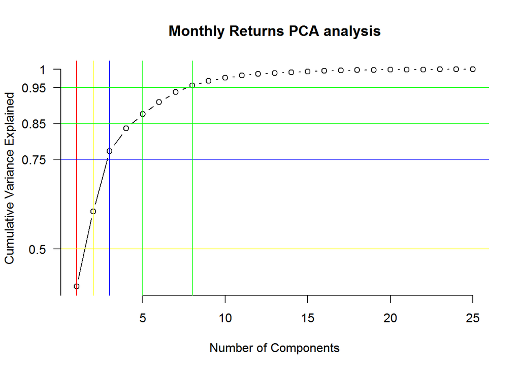

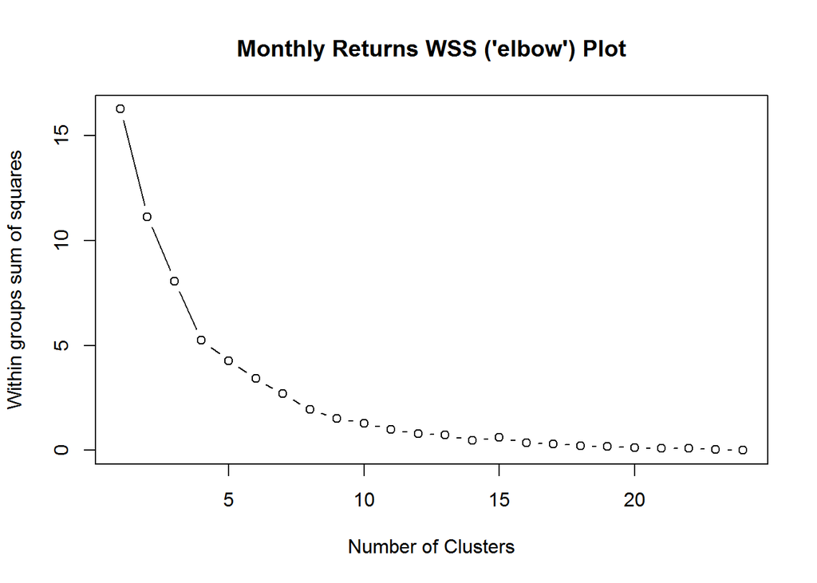

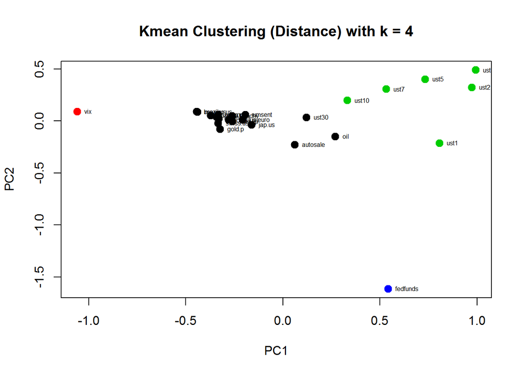

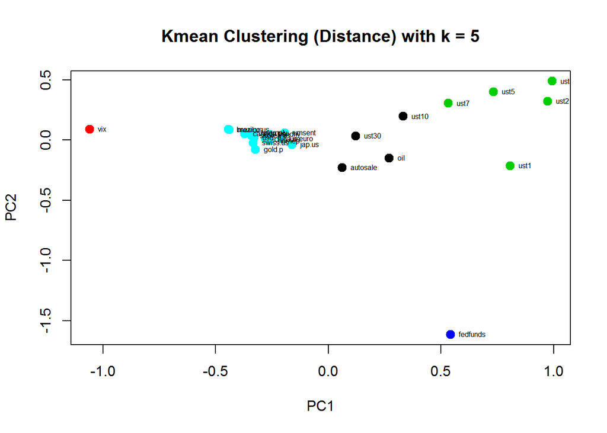

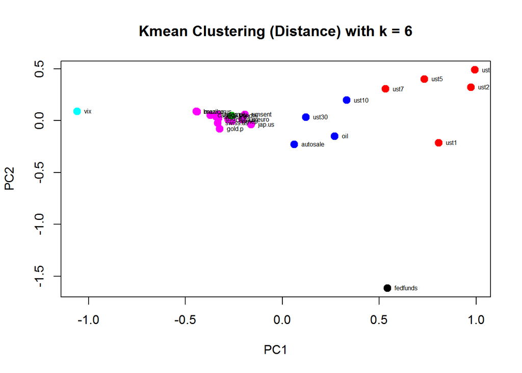

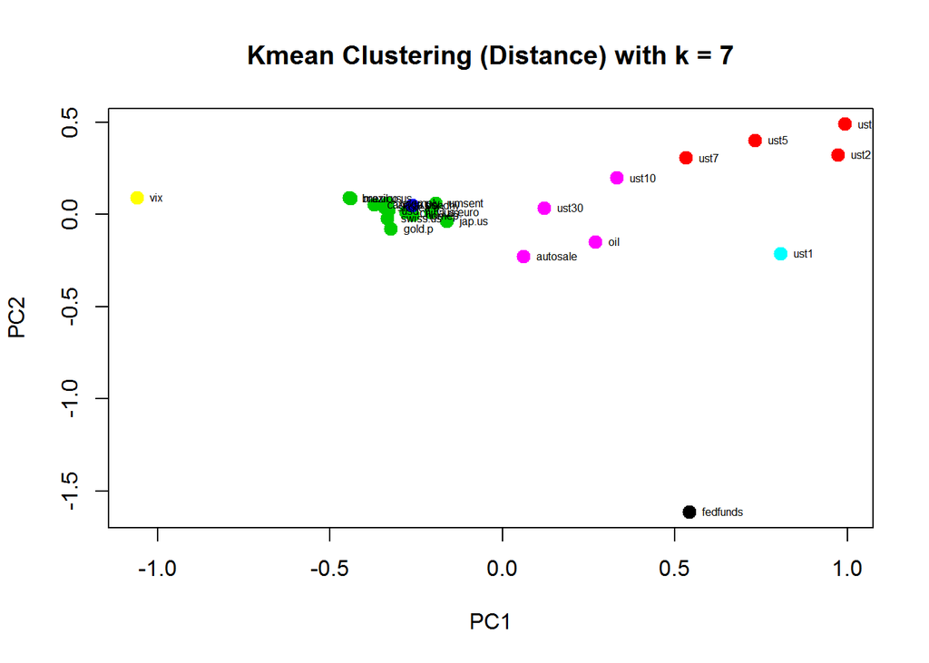

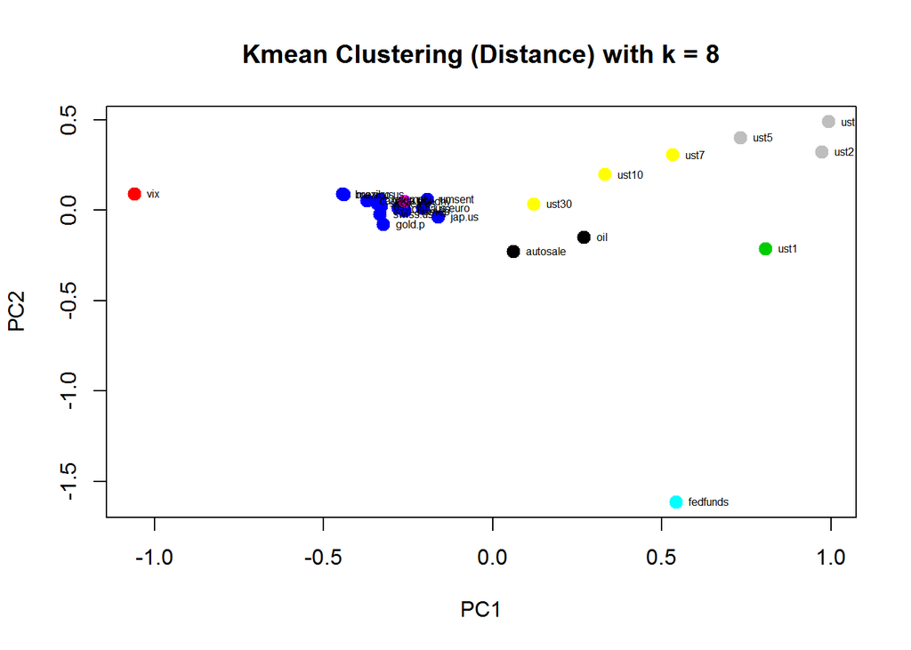

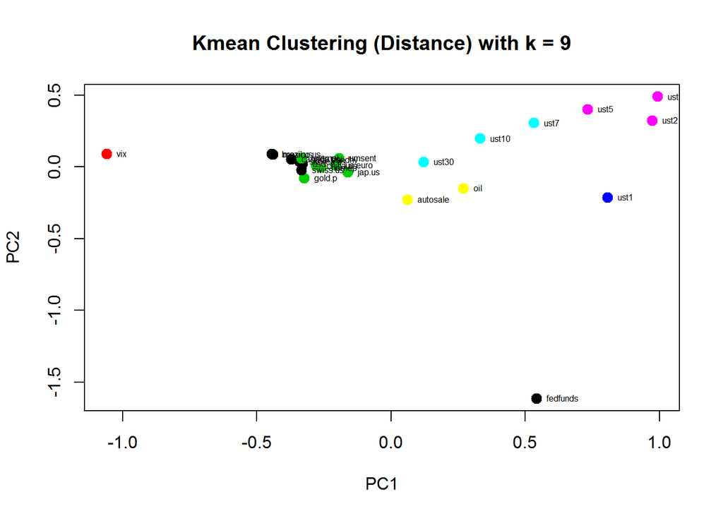

```r
test.kmeans(ret, 4, 9, add.labels = TRUE)
```